# Hair shedding & weaning weight phenotypic relationship

Harly Durbin

# Notes & questions

- Ideally, I’d pre-adjust with contemporary group solutions from the national run but I don’t have a way to match up renamed CG IDs to individuals
- What is the implication of the genetic correlation being higher than the phenotypic correlation?
  - Tbh I’d expect the phenotypic correlation to be higher
- Fescue NA is mostly AGI data
  - What’s up with weird differences between AGI and MU data

# Setup

```r
source(here::here("source_functions/hair_ped.R"))
```

```r
angus_join <-
  read_rds(here::here("data/derived_data/angus_join.rds"))
```

```r
hair_weights <-
  melt_hair_weights(path = here::here("data/raw_data/HairShedGrowthData_090919.csv"),
                    full_ped = hair_ped)
```

```r
calf_dam <-
  # All hair shedding growth data
  hair_weights %>%
  # filter down to just ww
  filter(trait == "ww") %>%
  # Column of how many animals per CG
  group_by(cg_num) %>%
  mutate(n_ww_cg = n()) %>%
  ungroup() %>%
  # Column of calf's weaning weight year
  mutate(year = lubridate::year(weigh_date)) %>%
  # Select only a few columns from growth data
  select(
    calf_reg = full_reg,
    full_reg = dam_reg,
    year,
    adj_weight,
    unadj_weight,
    calf_sex = sex,
    ww_cg = cg_num,
    n_ww_cg
  ) %>%
  # Join to full hair shedding data by dam and year
  right_join(angus_join,
             by = c("full_reg", "year")) %>%
  left_join(
    # Add contemporary group solution data to pre-adjust weaning weight phenotypes
    parse_renf90table(
      path = here::here("data/derived_data/ww_preadjust/renf90.tables"),
      effect = 1
    ) %>%
      left_join(
        read_table2(
          here::here("data/derived_data/ww_preadjust/solutions"),
          skip = 1,
          col_names = c("trait", "effect", "id_renamed", "solution")
        ) %>%
          filter(effect == 1)
      ) %>%
      # Join by ww_cg
      select(ww_cg = id_original,
             cg_sol = solution)
  ) %>%
  # cg adjusted weaning weight of calf
  mutate(cg_adj_ww = adj_weight - cg_sol,
         ww_cg = as_factor(ww_cg)) %>%
  # Attach dam's general hair shedding breeding value (in order to compare dam bv to calf phenotype)
  left_join(
    read_table2(
      here::here("data/derived_data/general_varcomp/normal/solutions"),
      skip = 1,
      col_names = c("trait", "effect", "renamed", "solution")
    ) %>%
      filter(effect == 2) %>%
      left_join(
        read_table2(
          here::here("data/derived_data/general_varcomp/normal/renadd02.ped"),
          col_names = FALSE
        ) %>%
          select(renamed = X1, full_reg = X10)
      ) %>%
      select(full_reg, bv = solution),
    by = c("full_reg")
  )
```

# Phenotypic correlation

```r
phencorr <-
  calf_dam  %>%
  select(full_reg, year, adj_weight, unadj_weight, cg_adj_ww, hair_score, bv, toxic_fescue) %>%
  filter(!is.na(adj_weight)) %>%
  mutate(toxic_fescue = if_else(toxic_fescue == "NO", "No", "Yes")) %>%
  tidyr::pivot_wider(
    names_from = toxic_fescue,
    values_from = hair_score,
    id_cols = -c("hair_score", "toxic_fescue")
  ) %>%
  select(-full_reg, -year) %>%
  bind_rows(calf_dam %>%
              select(adj_weight, unadj_weight, cg_adj_ww, bv, All = hair_score)) %>%
  set_names(
    c(
      "Calf's 205d WW",
      "Calf's unadjusted ww",
      "Calf's 205d + CG adjusted WW",
      "Dam BV",
      "Dam hair score (off fescue)",
      "Dam hair score (on fescue)",
      "Dam hair score (fescue NA)",
      "Dam hair score (all data)"
    )
  ) %>%
  corrr::correlate(diagonal = 1) %>%
  filter(!str_detect(rowname, "Calf's")) %>%
  tibble::column_to_rownames(var = "rowname")
```

## Pearson correlations

```r
phencorr %>%
  select(2, 1, 3) %>%
  DT::datatable(
    filter = 'none',
    extensions = list('FixedColumns', 'RowReorder'),
    options = list(
      fixedColumns = list(leftColumns = 1),
      rowReorder = FALSE
    )
  )
```

|  | Calf's unadjusted ww | Calf's 205d WW | Calf's 205d + CG adjusted WW |
| --- | --- | --- | --- |
| Dam BV | -0.0202297120530682 | -0.00308499860231308 | -0.0329052640111982 |
| Dam hair score (off fescue) | -0.119162353028553 | -0.113945892994269 | -0.0505116646152056 |
| Dam hair score (on fescue) | -0.0816150730363932 | -0.115607795111738 | -0.10171109893941 |
| Dam hair score (fescue NA) | -0.0605921992155863 | -0.0710484344946429 | -0.0330517845615546 |
| Dam hair score (all data) | -0.0317664808659454 | -0.0337784302528143 | -0.0622850883927237 |

```r
  #select(-contains("Dam"))
```

## Calculated using estimated covariances

- Have to use model 3 or 2 (residual covariance wasn’t fit in model 1)

```r
varcov3 <-
melt_aireml(
  path = here::here("data/derived_data/ww_genetic_corr/single_step/model3/airemlf90.model3.log"),
  effect2 = c("hair_dir", "ww_dir", "hair_mat", "ww_mat"),
  effect4 = c("hair_mpe", "ww_mpe"),
  resids = c("hair_res", "ww_res")
)
```

```r
herit3 <-
  varcov3 %>%
  biv_heritability(
    abbrvs = c("hair", "ww"),
    descs = c("Hair shedding", "Weaning weight"),
    mat = TRUE,
    mpe = TRUE
  )
```

```r
# Calculate square root of heritability for each hair shedding maternal, weaning weight maternal

h_hs <-
  herit3[[1, 4]] %>%
  sqrt(.)

h_ww <-
  herit3[[2, 4]] %>%
  sqrt(.)
```

```r
# e_x and e_y, where e^2 is 1-h^2

e_hs <-
  1-(herit3[[1,4]]) %>%
  sqrt(.)

e_ww <-
  1-(herit3[[2, 4]]) %>%
  sqrt(.)
```

```r
# Pull genetic correlation, residual correlation
r_a <-
  read_table2(
  here::here(
    "data/derived_data/ww_genetic_corr/single_step/model3/airemlf90.model3.log"
  ),
  skip = 9,
  n_max = 4,
  col_names = c(
    "Hair shedding (direct)",
    "Weaing weight (direct)",
    "Hair shedding (maternal)",
    "Weaning weight (milk)"
  )
)[[4,3]]

r_e <-
  read_table2(
  here::here(
    "data/derived_data/ww_genetic_corr/single_step/model3/airemlf90.model3.log"
  ),
  skip = 35,
  n_max = 2,
  col_names = c("hs", "ww")
)[[1,2]]
```

> Estimated phenotypic correlation (according to Falconer & McKay p. 313):
> $$r_p = \frac{cov_a+cov_e}{\sigma_{p_x}\sigma_{p_y}}; r_p = h_xh_yr_a+e_xe_yr_e$$

```r
(h_hs*h_ww*r_a)+(e_hs*e_ww*r_e)
```

```
## [1] -0.03257958
```

# Raw shedding score of dam vs. CG-adjusted 205d weaning weight of the calf she weaned that year

> In plot below, hair scores rounded to nearest whole number

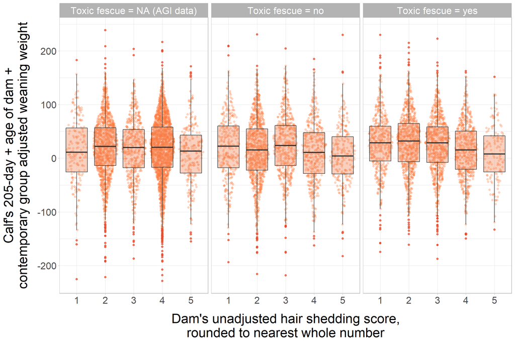

```r
calf_dam %>%
 # mutate(hair_score2 = round(hair_score/0.5)*0.5) %>%
  #filter(!is.na(toxic_fescue)) %>%
  mutate(hair_score2 = round(hair_score, 0),
         toxic_fescue = case_when(
           is.na(toxic_fescue) ~ "Toxic fescue = NA (AGI data)",
           toxic_fescue == "NO" ~ "Toxic fescue = no",
           toxic_fescue == "YES" ~ "Toxic fescue = yes"
         )) %>%
  ggplot(aes(x = as_factor(hair_score2),
             y = cg_adj_ww)) +
  ggforce::geom_sina(alpha = 0.3,
                     color = "#ff7436",
                     kernel = "rectangular") +
  geom_boxplot(outlier.color = "#e74a2f",
               outlier.alpha = 0.7,
               alpha = 0.4,
               fill = "#ef8759") +
  theme_light() +
  theme(
    plot.title = element_text(size = 28,
                              face = "italic"),
    plot.subtitle = element_text(size = 20,
                                 margin = margin(
                                   t = 0,
                                   r = 0,
                                   b = 13,
                                   l = 0
                                 )),
    legend.title = element_text(size = 18),
    legend.text = element_text(size = 14),
    axis.title = element_text(size = 22),
    axis.title.y = element_text(margin = margin(
      t = 0,
      r = 13,
      b = 0,
      l = 0
    )),
    axis.title.x = element_text(margin = margin(
      t = 13,
      r = 0,
      b = 0,
      l = 0
    )),
    axis.text = element_text(size = 16),
    strip.text.x = element_text(size = 16)
  ) +
  labs(x = "Dam's unadjusted hair shedding score,\nrounded to nearest whole number",
       y = "Calf's 205-day + age of dam +\ncontemporary group adjusted weaning weight"
       ) +
  facet_wrap(~toxic_fescue)
```

```r
#cowplot::ggsave2(filename = here::here("figures/hair_ww_boxswarm_stratified.png"), width = 12, height = 8, dpi = 500)
```

## Simple linear model predicting 205d + age-of-dam + CG adjusted weight from dam hair score

### All

```r
ww_hair_simple_all <- lm(cg_adj_ww ~ hair_score, data = calf_dam)
```

```r
summary(ww_hair_simple_all)
```

```
##
## Call:
## lm(formula = cg_adj_ww ~ hair_score, data = calf_dam)
##
## Residuals:
##      Min       1Q   Median       3Q      Max
## -250.361  -35.243    1.877   37.722  218.845
##
## Coefficients:
##             Estimate Std. Error t value Pr(>|t|)
## (Intercept)  28.0216     1.6079  17.428  < 2e-16 ***
## hair_score   -3.1287     0.5107  -6.126 9.35e-10 ***
## ---
## Signif. codes:  0 '***' 0.001 '**' 0.01 '*' 0.05 '.' 0.1 ' ' 1
##
## Residual standard error: 57.92 on 9637 degrees of freedom
##   (5196 observations deleted due to missingness)
## Multiple R-squared:  0.003879,   Adjusted R-squared:  0.003776
## F-statistic: 37.53 on 1 and 9637 DF,  p-value: 9.346e-10
```

### Toxic fescue = YES

```r
ww_hair_mixed_yes <- lme4::lmer(adj_weight ~ hair_score + (1|ww_cg), data = calf_dam %>% filter(toxic_fescue == "YES"))
```

```r
ww_hair_simple_yes <- lm(cg_adj_ww ~ hair_score, data = calf_dam %>% filter(toxic_fescue == "YES"))
```

```r
summary(ww_hair_simple_yes)
```

```
##
## Call:
## lm(formula = cg_adj_ww ~ hair_score, data = calf_dam %>% filter(toxic_fescue ==
##     "YES"))
##
## Residuals:
##      Min       1Q   Median       3Q      Max
## -210.000  -35.006    1.655   35.011  200.625
##
## Coefficients:
##             Estimate Std. Error t value Pr(>|t|)
## (Intercept)  37.1237     2.6518  13.999  < 2e-16 ***
## hair_score   -4.9553     0.9122  -5.432 6.04e-08 ***
## ---
## Signif. codes:  0 '***' 0.001 '**' 0.01 '*' 0.05 '.' 0.1 ' ' 1
##
## Residual standard error: 54.9 on 2823 degrees of freedom
##   (3243 observations deleted due to missingness)
## Multiple R-squared:  0.01035,    Adjusted R-squared:  0.009995
## F-statistic: 29.51 on 1 and 2823 DF,  p-value: 6.038e-08
```

### Toxic fescue = NO

```r
ww_hair_mixed_no <- lme4::lmer(adj_weight ~ hair_score + (1|ww_cg), data = calf_dam %>% filter(toxic_fescue == "NO"))
```

```r
ww_hair_simple_no <- lm(cg_adj_ww ~ hair_score, data = calf_dam %>% filter(toxic_fescue == "NO"))
```

```r
summary(ww_hair_simple_no)
```

```
##
## Call:
## lm(formula = cg_adj_ww ~ hair_score, data = calf_dam %>% filter(toxic_fescue ==
##     "NO"))
##
## Residuals:
##      Min       1Q   Median       3Q      Max
## -234.314  -37.695    0.949   39.056  219.635
##
## Coefficients:
##             Estimate Std. Error t value Pr(>|t|)
## (Intercept)  22.7647     2.8783   7.909  3.8e-15 ***
## hair_score   -2.4639     0.9567  -2.575   0.0101 *
## ---
## Signif. codes:  0 '***' 0.001 '**' 0.01 '*' 0.05 '.' 0.1 ' ' 1
##
## Residual standard error: 59.21 on 2593 degrees of freedom
##   (1711 observations deleted due to missingness)
## Multiple R-squared:  0.002551,   Adjusted R-squared:  0.002167
## F-statistic: 6.633 on 1 and 2593 DF,  p-value: 0.01007
```

# Raw shedding score of dam vs. **unadjusted** weaning weight of the calf she weaned that year

> In plot below, hair scores rounded to nearest whole number

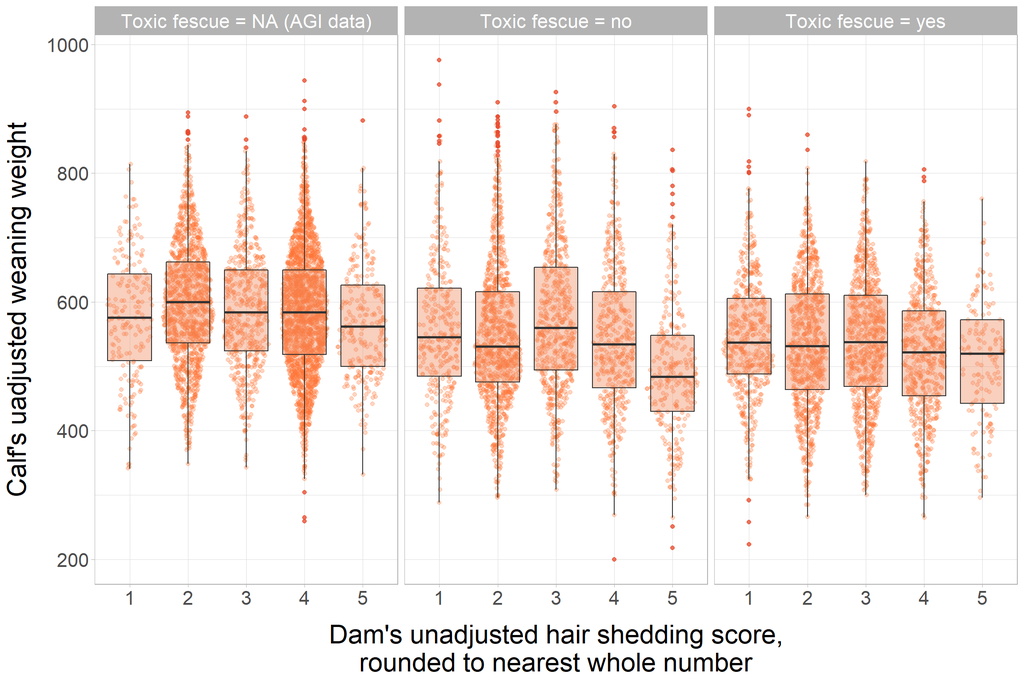

```r
calf_dam %>%
 # mutate(hair_score2 = round(hair_score/0.5)*0.5) %>%
  #filter(!is.na(toxic_fescue)) %>%
  mutate(hair_score2 = round(hair_score, 0),
         toxic_fescue = case_when(
           is.na(toxic_fescue) ~ "Toxic fescue = NA (AGI data)",
           toxic_fescue == "NO" ~ "Toxic fescue = no",
           toxic_fescue == "YES" ~ "Toxic fescue = yes"
         )) %>%
  ggplot(aes(x = as_factor(hair_score2),
             y = unadj_weight)) +
  ggforce::geom_sina(alpha = 0.3,
                     color = "#ff7436",
                     kernel = "rectangular") +
  geom_boxplot(outlier.color = "#e74a2f",
               outlier.alpha = 0.7,
               alpha = 0.4,
               fill = "#ef8759") +
  theme_light() +
  theme(
    plot.title = element_text(size = 28,
                              face = "italic"),
    plot.subtitle = element_text(size = 20,
                                 margin = margin(
                                   t = 0,
                                   r = 0,
                                   b = 13,
                                   l = 0
                                 )),
    legend.title = element_text(size = 18),
    legend.text = element_text(size = 14),
    axis.title = element_text(size = 22),
    axis.title.y = element_text(margin = margin(
      t = 0,
      r = 13,
      b = 0,
      l = 0
    )),
    axis.title.x = element_text(margin = margin(
      t = 13,
      r = 0,
      b = 0,
      l = 0
    )),
    axis.text = element_text(size = 16),
    strip.text.x = element_text(size = 16)
  ) +
  labs(x = "Dam's unadjusted hair shedding score,\nrounded to nearest whole number",
       y = "Calf's uadjusted weaning weight"
       ) +
  facet_wrap(~toxic_fescue)
```

```r
#cowplot::ggsave2(filename = here::here("figures/hair_ww_boxswarm_stratified.png"), width = 12, height = 8, dpi = 500)
```

## Simple linear model predicting unadjusted weight from dam hair score

### All

```r
ww_hair_unadj_all <- lm(unadj_weight ~ hair_score, data = calf_dam)
```

```r
summary(ww_hair_unadj_all)
```

```
##
## Call:
## lm(formula = unadj_weight ~ hair_score, data = calf_dam)
##
## Residuals:
##     Min      1Q  Median      3Q     Max
## -359.45  -72.05   -4.89   69.95  407.95
##
## Coefficients:
##             Estimate Std. Error t value Pr(>|t|)
## (Intercept) 570.9124     2.8415 200.918  < 2e-16 ***
## hair_score   -2.8645     0.9029  -3.172  0.00152 **
## ---
## Signif. codes:  0 '***' 0.001 '**' 0.01 '*' 0.05 '.' 0.1 ' ' 1
##
## Residual standard error: 104.5 on 9963 degrees of freedom
##   (4870 observations deleted due to missingness)
## Multiple R-squared:  0.001009,   Adjusted R-squared:  0.0009088
## F-statistic: 10.06 on 1 and 9963 DF,  p-value: 0.001517
```

### Toxic fescue = YES

```r
ww_hair_unadj_yes <- lm(unadj_weight ~ hair_score, data = calf_dam %>% filter(toxic_fescue == "YES"))
```

```r
summary(ww_hair_unadj_yes)
```

```
##
## Call:
## lm(formula = unadj_weight ~ hair_score, data = calf_dam %>% filter(toxic_fescue ==
##     "YES"))
##
## Residuals:
##     Min      1Q  Median      3Q     Max
## -323.12  -68.12   -3.01   68.99  353.88
##
## Coefficients:
##             Estimate Std. Error t value Pr(>|t|)
## (Intercept)  553.220      4.623 119.679  < 2e-16 ***
## hair_score    -7.104      1.600  -4.439 9.35e-06 ***
## ---
## Signif. codes:  0 '***' 0.001 '**' 0.01 '*' 0.05 '.' 0.1 ' ' 1
##
## Residual standard error: 98.56 on 2939 degrees of freedom
##   (3127 observations deleted due to missingness)
## Multiple R-squared:  0.006661,   Adjusted R-squared:  0.006323
## F-statistic: 19.71 on 1 and 2939 DF,  p-value: 9.355e-06
```

### Toxic fescue = NO

```r
ww_hair_unadj_no <- lm(unadj_weight ~ hair_score, data = calf_dam %>% filter(toxic_fescue == "NO"))
```

```r
summary(ww_hair_unadj_no)
```

```
##
## Call:
## lm(formula = unadj_weight ~ hair_score, data = calf_dam %>% filter(toxic_fescue ==
##     "NO"))
##
## Residuals:
##     Min      1Q  Median      3Q     Max
## -336.79  -78.01  -15.70   67.03  405.56
##
## Coefficients:
##             Estimate Std. Error t value Pr(>|t|)
## (Intercept)  581.660      5.438 106.953  < 2e-16 ***
## hair_score   -11.217      1.801  -6.229 5.42e-10 ***
## ---
## Signif. codes:  0 '***' 0.001 '**' 0.01 '*' 0.05 '.' 0.1 ' ' 1
##
## Residual standard error: 113.7 on 2694 degrees of freedom
##   (1610 observations deleted due to missingness)
## Multiple R-squared:  0.0142, Adjusted R-squared:  0.01383
## F-statistic:  38.8 on 1 and 2694 DF,  p-value: 5.417e-10
```

# Breeding value of dam vs. CG-adjusted 205d weaning weight

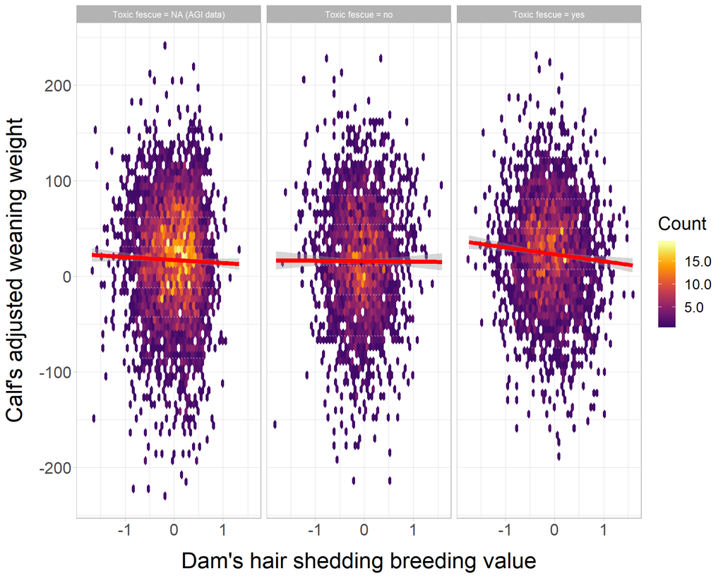

```r
calf_dam %>%
  mutate(
    hair_score2 = round(hair_score, 0),
    toxic_fescue = case_when(
      is.na(toxic_fescue) ~ "Toxic fescue = NA (AGI data)",
      toxic_fescue == "NO" ~ "Toxic fescue = no",
      toxic_fescue == "YES" ~ "Toxic fescue = yes"
    )
  ) %>%
  ggplot(aes(x = bv, y = cg_adj_ww)) +
  geom_hex(aes(fill = stat(count)),
           bins = 55) +
  viridis::scale_fill_viridis(
    option = "inferno",
    direction = 1,
    begin = 0.2,
    labels = scales::comma
  ) +
  geom_smooth(method = "lm",
              color = "red",
              size = 2) +
  theme_light() +
  theme(
    plot.title = element_text(size = 28,
                              face = "italic"),
    plot.subtitle = element_text(size = 20,
                                 margin = margin(
                                   t = 0,
                                   r = 0,
                                   b = 13,
                                   l = 0
                                 )),
    legend.title = element_text(size = 18),
    legend.text = element_text(size = 14),
    axis.title = element_text(size = 22),
    axis.title.y = element_text(margin = margin(
      t = 0,
      r = 13,
      b = 0,
      l = 0
    )),
    axis.title.x = element_text(margin = margin(
      t = 13,
      r = 0,
      b = 0,
      l = 0
    )),
    axis.text = element_text(size = 16)
  ) +
  labs(x = "Dam's hair shedding breeding value",
       y = "Calf's adjusted weaning weight",
       fill = "Count") +
  facet_wrap(~ toxic_fescue)
```

# Data missingness?

- Results compared to original Angus results and results in other breeds are underwhelming. Is that a function of data missingness/under-reporting?
  - Doesn’t appear so

```r
calf_dam %>%
  # Round to nearest whole score
  mutate(hair_whole = round(hair_score, 0)) %>%
  group_by(hair_whole) %>%
  summarise(
    n_scores = n(),
    n_missing = sum(is.na(adj_weight)),
    percent_missing = scales::percent(sum(is.na(adj_weight))/n()))
```

| hair_whole | n_scores | n_missing | percent_missing |
| --- | --- | --- | --- |
| 1 | 1873 | 825 | 44% |
| 2 | 4604 | 1486 | 32% |
| 3 | 3281 | 1321 | 40% |
| 4 | 4036 | 883 | 22% |
| 5 | 1041 | 355 | 34% |

# Contemporary group effect: on vs. off toxic fescue

> Appears that calfs of dams grazing toxic fescue get the most “boost” from contemporary grouping?

```r
calf_dam %>%
  filter(!is.na(toxic_fescue)) %>%
  select(full_reg,
         toxic_fescue,
         hair_score,
         unadj_weight,
         cg_adj_ww) %>%
  tidyr::pivot_longer(
    cols = c("unadj_weight", "cg_adj_ww"),
    names_to = "weight_type",
    values_to = "weight"
  ) %>%
  bind_rows(
    calf_dam %>%
      select(
        full_reg,
        toxic_fescue,
        hair_score,
        unadj_weight,
        adj_weight,
        cg_adj_ww
      ) %>%
      tidyr::pivot_longer(
        cols = c("unadj_weight", "cg_adj_ww"),
        names_to = "weight_type",
        values_to = "weight"
      ) %>%
      mutate(toxic_fescue = "ALL")
  ) %>%
  filter(!is.na(weight)) %>%
  group_by(toxic_fescue, weight_type) %>%
  summarise(mean = mean(weight),
            #sd = sd(weight)
            ) %>%
  ungroup() %>%
  tidyr::pivot_wider(names_from = "weight_type", values_from = "mean", names_prefix = "mean_")
```

| toxic_fescue | mean_cg_adj_ww | mean_unadj_weight |
| --- | --- | --- |
| ALL | 18.85835 | 562.5322 |
| NO | 15.98321 | 550.6487 |
| YES | 23.85571 | 534.3512 |

```r
calf_dam %>%
  filter(!is.na(toxic_fescue)) %>%
  select(toxic_fescue, cg_sol) %>%
  bind_rows(calf_dam %>%
              select(toxic_fescue, cg_sol) %>%
              mutate(toxic_fescue = "ALL")
              ) %>%
  filter(!is.na(cg_sol)) %>%
  group_by(toxic_fescue) %>%
  summarise(mean_cg_sol = mean(cg_sol))
```

| toxic_fescue | mean_cg_sol |
| --- | --- |
| ALL | 567.3580 |
| NO | 570.8842 |
| YES | 525.1415 |

# Commentary

## Weaning weight figure for manuscript

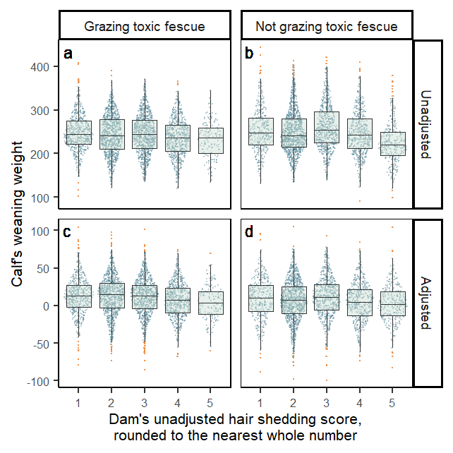

```r
calf_dam %>%
  filter(!is.na(toxic_fescue)) %>%
  select(full_reg,
         toxic_fescue,
         hair_score,
         unadj_weight,
         adj_weight,
         cg_adj_ww) %>%
  tidyr::pivot_longer(
    cols = c("unadj_weight", "adj_weight", "cg_adj_ww"),
    names_to = "weight_type",
    values_to = "weight"
  ) %>%
  filter(!is.na(weight)) %>%
  filter(weight_type != "adj_weight") %>%
  mutate(
    weight = measurements::conv_unit(weight, from = "lbs", to = "kg"),
    # figure tags for publication
    tag = case_when(
      toxic_fescue == "NO" & weight_type == "unadj_weight" ~ "b",
      toxic_fescue == "YES" & weight_type == "unadj_weight" ~ "a",
      toxic_fescue == "NO" & weight_type == "cg_adj_ww" ~ "d",
      toxic_fescue == "YES" & weight_type == "cg_adj_ww" ~ "c"
    ),
    hair_score2 = round(hair_score, 0),
    toxic_fescue = case_when(
      toxic_fescue == "NO" ~ "Not grazing toxic fescue",
      toxic_fescue == "YES" ~ "Grazing toxic fescue"
    ),
    weight_type = case_when(
      weight_type == "unadj_weight" ~ "Unadjusted",
      weight_type == "adj_weight" ~ "205-day + age-of-dam adjusted",
      weight_type == "cg_adj_ww" ~ "Adjusted",
    ),
    weight_type = forcats::fct_relevel(
      weight_type,
      c(
        "Unadjusted",
        "205-day + age-of-dam adjusted",
        "205-day + age-of-dam + CG adjusted"
      )
    )
  ) %>%
  ggplot(aes(x = as_factor(hair_score2),
             y = weight)) +
  ggforce::geom_sina(alpha = 0.3,
                     # dark blue
                     color = "#538797",
                     kernel = "rectangular",
                     size = 0.01) +
  geom_boxplot(
    #orange
    outlier.color = "#FF842A",
    size = 0.01,
    outlier.alpha = 0.7,
    outlier.size = 0.01,
    alpha = 0.4,
    # light blue
    fill = "#C2D9CD"
  ) +
  theme_classic() +
  theme(
    axis.title = element_text(size = 8),
    axis.title.y = element_text(margin = margin(
      t = 0,
      r = 1.5,
      b = 0,
      l = 0
    )),
    axis.title.x = element_text(margin = margin(
      t = 2,
      r = 0,
      b = 0,
      l = 0
    )),
    axis.text = element_text(size = 6),
    strip.text = element_text(size = 7)
  ) +
    geom_text(aes(x = -Inf, y = Inf, label = tag, group = tag),
        size = 3,
        hjust = -0.5,
        vjust = 1.4,
        inherit.aes = FALSE) +
  labs(x = "Dam's unadjusted hair shedding score,\nrounded to the nearest whole number",
       y = "Calf's weaning weight") +
  facet_grid(weight_type ~ toxic_fescue, scales = "free_y") +
  theme(panel.background = element_rect(fill = NA, color = "black"))
```

```r
ggsave(here::here("figures/figure5.weight_fescue_facet.pdf"), height = 85, width = 85, units = c("mm"), dpi = 300)
```